# Computer Practical 1: Introduction to R and plotting with ggplot2

# 7 Data types

In your working environment, you should now see this:

[figure not shown]

**If it doesn’t look like this, make sure the work environment is in ‘grid’ format by clicking on the ‘list’ button and clicking ‘grid’ in the drop down menu.**

The work environment gives you a summary of the data you have saved to your environment. The most important information is ‘Type’, which stats for ‘Data type’. This tells you what kind of data R thinks it is.

In the lecture, I mentioned that there are different types of data - **numerical** and **non-numerical (categorical),** and numerical data can be further split into **continuous data** and **count data.**

[figure not shown]

In R (and indeed any other statistical software), it is VERY important to always be explicit about what type of data you have. The three main types of data and how they are called in R are:

| Data type | R terminology | R function to specify data type |
| --- | --- | --- |
| Categorical | FACTOR (“factor”) or CHARACTER (“chr”) | as.factor() or as.character() |
| Continuous | NUMERIC (“num”) | as.numeric() |
| Count | INTEGER (“int”) | as.integer() |

**NOTE 1:** Categorical data in R can be treated as either FACTOR data or CHARACTER data. Often, it doesn’t matter. However, for analyses you will usually want your categorical data treated as a FACTOR.

Look at your work environment again. R has assumed *a* and *b* are continuous numeric data, and *tutees* is character (categorical) data. Lets specify that we want *a* and *b* to in count data, and *tutees* to be categorical data.

```r
a <- as.integer(a) # assign a into count data
b <- as.integer(b) # assign b as count data
tutees <- as.factor(tutees) # assign tutees as categorical data
```

You should now see that R has changed the data type of your three objects in your work environment.

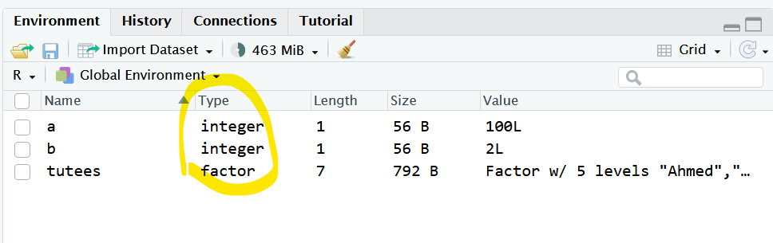

# 8 Load the ‘pirate’ dataset

Now we have covered some of the basics of R, time to dig into some data!

**First, lets install and load an example dataset about pirates, which is available from the R package “yarrr”.** This dataset is called ‘*pirates*’ and contains the results of a survey of 1000 pirates, including info on their sex, age, height, how many tattoos they have, number of parrots they own, whether they have an eye patch, who their favourite pirate is, etc.

**From now on, make sure all your code is copied into the code editor window, and not directly into the console. This is so you can save it and return to it next week.**

```r
install.packages("yarrr") # install package
```

```r
library(yarrr) # load package

data("pirates") # extract the data frame 'pirates' and save into working env

head(pirates) # returns the first six lines of the dataset
```

|  | id | sex | age | height | weight | headband | college | tattoos | tchests | parrots | favorite.pirate | sword.type | eyepatch | sword.time | beard.length | fav.pixar | grogg |
| --- | --- | --- | --- | --- | --- | --- | --- | --- | --- | --- | --- | --- | --- | --- | --- | --- | --- |
| 1 | 1 | male | 28 | 173.11 | 70.5 | yes | JSSFP | 9 | 0 | 0 | Jack Sparrow | cutlass | 1 | 0.58 | 16 | Monsters, Inc. | 11 |
| 2 | 2 | male | 31 | 209.25 | 105.6 | yes | JSSFP | 9 | 11 | 0 | Jack Sparrow | cutlass | 0 | 1.11 | 21 | WALL-E | 9 |
| 3 | 3 | male | 26 | 169.95 | 77.1 | yes | CCCC | 10 | 10 | 1 | Jack Sparrow | cutlass | 1 | 1.44 | 19 | Inside Out | 7 |
| 4 | 4 | female | 31 | 144.29 | 58.5 | no | JSSFP | 2 | 0 | 2 | Jack Sparrow | scimitar | 1 | 36.11 | 2 | Inside Out | 9 |
| 5 | 5 | female | 41 | 157.85 | 58.4 | yes | JSSFP | 9 | 6 | 4 | Hook | cutlass | 1 | 0.11 | 0 | Inside Out | 14 |
| 6 | 6 | male | 26 | 190.20 | 85.4 | yes | CCCC | 7 | 19 | 0 | Jack Sparrow | cutlass | 1 | 0.59 | 17 | Monsters University | 7 |

```r
dim(pirates) # dimensions of the dataset. It has 1000 rows and 17 columns
```

```
## [1] 1000   17
```

```r
names(pirates) # column names. These are important for plotting!
```

```
##  [1] "id"              "sex"             "age"             "height"
##  [5] "weight"          "headband"        "college"         "tattoos"
##  [9] "tchests"         "parrots"         "favorite.pirate" "sword.type"
## [13] "eyepatch"        "sword.time"      "beard.length"    "fav.pixar"
## [17] "grogg"
```

The dataset contains the following data:

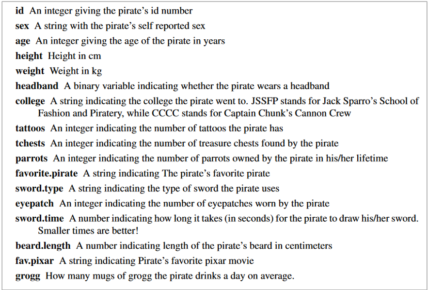

To view your dataset in a separate window, you use the function **View()**. This will add a new tab on your code editor window and you will need to click back on your R script to continue coding. In View pane, you can click on the column names to sort the rows, just as you can in Excel.

```r
View(pirates) # View the dataset in a seperate window
```

**NOTE 1:** Have you noticed that none of the column names contain spaces? When naming columns for your own data in Excel, never put spaces in the column names, as this will confuse all statistical software at the data analysis stage.

In this dataset, all column names are lower case and words are separated by full stop. T*his will be important to remember when plotting.*

**To check the names of your columns (“variables”) you can either look at your dataset using the View() function, or use the names() function.**

```r
names(pirates)
```

```
##  [1] "id"              "sex"             "age"             "height"
##  [5] "weight"          "headband"        "college"         "tattoos"
##  [9] "tchests"         "parrots"         "favorite.pirate" "sword.type"
## [13] "eyepatch"        "sword.time"      "beard.length"    "fav.pixar"
## [17] "grogg"
```

You may want to look at data from a specific column. To call a specific column, you use the the **$** sign using the structure *data$column.*

```r
pirates$id # Pirate ID
```

```
##    [1]    1    2    3    4    5    6    7    8    9   10   11   12   13   14
##   [15]   15   16   17   18   19   20   21   22   23   24   25   26   27   28
##   [29]   29   30   31   32   33   34   35   36   37   38   39   40   41   42
##   [43]   43   44   45   46   47   48   49   50   51   52   53   54   55   56
##   [57]   57   58   59   60   61   62   63   64   65   66   67   68   69   70
##   [71]   71   72   73   74   75   76   77   78   79   80   81   82   83   84
##   [85]   85   86   87   88   89   90   91   92   93   94   95   96   97   98
##   [99]   99  100  101  102  103  104  105  106  107  108  109  110  111  112
##  [113]  113  114  115  116  117  118  119  120  121  122  123  124  125  126
##  [127]  127  128  129  130  131  132  133  134  135  136  137  138  139  140
##  [141]  141  142  143  144  145  146  147  148  149  150  151  152  153  154
##  [155]  155  156  157  158  159  160  161  162  163  164  165  166  167  168
##  [169]  169  170  171  172  173  174  175  176  177  178  179  180  181  182
##  [183]  183  184  185  186  187  188  189  190  191  192  193  194  195  196
##  [197]  197  198  199  200  201  202  203  204  205  206  207  208  209  210
```

[output cut: 57 more lines]

```r
pirates$age # Shows all data from the Age column
```

```
##    [1] 28 31 26 31 41 26 31 31 28 30 25 20 24 26 45 40 21 30 35 26 22 34 23 12
##   [25] 35 26 15 30 17 26 22 22 31 30 23 18 27 31 25 36 24 27 26 28 28 24 23 27
##   [49] 20 28 26 35 27 38 18 24 26 30 25 32 37 19 26 32 23 22 21 32 28 21 35 20
##   [73] 24 38 21 34 19 25 18 36 35 22 21 15 28 28 24 34 15 15 22 31 29 20 45 35
##   [97] 22 17 29 33 33 23 31 20 25 19 26 26 29 34 30 26 29 27 29 17 31 19 30 16
##  [121] 33 26 18 37 33 30 39 32 28 32 32 21 30 16 34 22 25 31 27 30 31 26 29 31
##  [145] 31 26 29 19 13 26 31 36 29 34 22 26 34 26 32 26 20 22 18 22 36 21 25 34
##  [169] 23 26 21 28 19 36 29 33 14 27 33 20 20 24 34 29 35 27 20 39 33 28 25 32
##  [193] 26 30 29 27 26 36 33 30 18 21 28 35 20 23 32 22 27 32 32 26 26 29 27 33
##  [217] 34 22 34 28 30 24 28 24 25 30 32 26 31 31 26 38 29 26 22 21 24 29 40 35
##  [241] 27 27 34 27 17 33 28 19 22 25 33 23 37 18 28 22 33 34 20 31 22 27 27 20
##  [265] 29 22 32 29 26 27 31 26 24 35 32 28 20 28 26 27 36 25 21 21 22 30 30 17
##  [289] 22 28 32 29 23 25 33 28 31 33 19 32 38 17 26 29 27 38 37 31 29 27 39 32
##  [313] 36 28 31 26 34 33 37 23 25 25 24 24 34 24 16 15 26 41 24 34 24 33 31 28
##  [337] 26 25 18 31 30 27 26 32 31 29 26 24 21 20 36 22 25 25 28 21 30 30 33 32
```

[output cut: 27 more lines]

```r
pirates$favorite.pirate # Calls all data from the favourite.pirate column
```

```
##    [1] "Jack Sparrow" "Jack Sparrow" "Jack Sparrow" "Jack Sparrow"
##    [5] "Hook"         "Jack Sparrow" "Blackbeard"   "Hook"
##    [9] "Anicetus"     "Jack Sparrow" "Blackbeard"   "Jack Sparrow"
##   [13] "Lewis Scot"   "Jack Sparrow" "Hook"         "Hook"
##   [17] "Jack Sparrow" "Blackbeard"   "Hook"         "Jack Sparrow"
##   [21] "Jack Sparrow" "Edward Low"   "Edward Low"   "Jack Sparrow"
##   [25] "Jack Sparrow" "Blackbeard"   "Jack Sparrow" "Edward Low"
##   [29] "Hook"         "Edward Low"   "Jack Sparrow" "Hook"
##   [33] "Jack Sparrow" "Jack Sparrow" "Hook"         "Jack Sparrow"
##   [37] "Lewis Scot"   "Lewis Scot"   "Edward Low"   "Anicetus"
##   [41] "Jack Sparrow" "Edward Low"   "Edward Low"   "Jack Sparrow"
##   [45] "Jack Sparrow" "Blackbeard"   "Lewis Scot"   "Lewis Scot"
##   [49] "Jack Sparrow" "Lewis Scot"   "Jack Sparrow" "Anicetus"
##   [53] "Jack Sparrow" "Lewis Scot"   "Jack Sparrow" "Jack Sparrow"
##   [57] "Jack Sparrow" "Anicetus"     "Jack Sparrow" "Hook"
```

[output cut: 235 more lines]

```r
head(pirates$fav.pixar) # first six rows of the fav.pixar column.
```

```
## [1] "Monsters, Inc."      "WALL-E"              "Inside Out"
## [4] "Inside Out"          "Inside Out"          "Monsters University"
```

# 9 Changing data types

The first thing you should do when you import a new dataset is to check how R has assigned the data type of each column. To do this you use the function str() (which stands for *structure*).

```r
str(pirates) # show the data types R has assigned for each column
```

```
## 'data.frame':    1000 obs. of  17 variables:
##  $ id             : int  1 2 3 4 5 6 7 8 9 10 ...
##  $ sex            : chr  "male" "male" "male" "female" ...
##  $ age            : num  28 31 26 31 41 26 31 31 28 30 ...
##  $ height         : num  173 209 170 144 158 ...
##  $ weight         : num  70.5 105.6 77.1 58.5 58.4 ...
##  $ headband       : chr  "yes" "yes" "yes" "no" ...
##  $ college        : chr  "JSSFP" "JSSFP" "CCCC" "JSSFP" ...
##  $ tattoos        : num  9 9 10 2 9 7 9 5 12 12 ...
##  $ tchests        : num  0 11 10 0 6 19 1 13 37 69 ...
##  $ parrots        : num  0 0 1 2 4 0 7 7 2 4 ...
##  $ favorite.pirate: chr  "Jack Sparrow" "Jack Sparrow" "Jack Sparrow" "Jack Sparrow" ...
##  $ sword.type     : chr  "cutlass" "cutlass" "cutlass" "scimitar" ...
##  $ eyepatch       : num  1 0 1 1 1 1 0 1 0 1 ...
##  $ sword.time     : num  0.58 1.11 1.44 36.11 0.11 ...
##  $ beard.length   : num  16 21 19 2 0 17 1 1 1 25 ...
##  $ fav.pixar      : chr  "Monsters, Inc." "WALL-E" "Inside Out" "Inside Out" ...
##  $ grogg          : num  11 9 7 9 14 7 9 12 16 9 ...
```

Do you think these data assignments are correct? You will need to change the data types for some of the columns.

At least one column is clearly wrong in its assigned data types. This is pirate ID. PirateID is down as numeric data, but it is actually catagorical (a pirate’s identity cannot be treated as continuous or count data). However - many other columns are also incorrectly categorised (e.g., is number of parrots numerical or count data?).

The code for converting pirate ID into categorical data and converting number of tattoos into count data has been provided (run this code).

```r
pirates$id <- as.factor(pirates$id) # assign pirate ID as categorical data

pirates$tattoos <- as.integer(pirates$tattoos) # assign number of tattoos as count data
```

## 9.1 **Exercise 3**

Convert the columns for number of parrots and treasure chests (*tchests*) into count data, and convert the column for sword type into a factor (i.e., categorical data).

You will need the functions **as.integer()** and **as.factor(). Once you have worked it out, copy the correct code below:**

```r
pirates$parrots <- as.integer(pirates$parrots)
pirates$sword.type <- as.factor(pirates$sword.type)

str(pirates) # check the data type for these variables has changed
```

```
## 'data.frame':    1000 obs. of  17 variables:
##  $ id             : Factor w/ 1000 levels "1","2","3","4",..: 1 2 3 4 5 6 7 8 9 10 ...
##  $ sex            : chr  "male" "male" "male" "female" ...
##  $ age            : num  28 31 26 31 41 26 31 31 28 30 ...
##  $ height         : num  173 209 170 144 158 ...
##  $ weight         : num  70.5 105.6 77.1 58.5 58.4 ...
##  $ headband       : chr  "yes" "yes" "yes" "no" ...
##  $ college        : chr  "JSSFP" "JSSFP" "CCCC" "JSSFP" ...
##  $ tattoos        : int  9 9 10 2 9 7 9 5 12 12 ...
##  $ tchests        : num  0 11 10 0 6 19 1 13 37 69 ...
##  $ parrots        : int  0 0 1 2 4 0 7 7 2 4 ...
##  $ favorite.pirate: chr  "Jack Sparrow" "Jack Sparrow" "Jack Sparrow" "Jack Sparrow" ...
##  $ sword.type     : Factor w/ 4 levels "banana","cutlass",..: 2 2 2 4 2 2 2 2 2 2 ...
##  $ eyepatch       : num  1 0 1 1 1 1 0 1 0 1 ...
##  $ sword.time     : num  0.58 1.11 1.44 36.11 0.11 ...
##  $ beard.length   : num  16 21 19 2 0 17 1 1 1 25 ...
##  $ fav.pixar      : chr  "Monsters, Inc." "WALL-E" "Inside Out" "Inside Out" ...
##  $ grogg          : num  11 9 7 9 14 7 9 12 16 9 ...
```

# 10 Summary (descriptive) statistics

Lets have a look at some summary statistics. To get summary statistics for numerical data, you use the function summary(). To get summary statistics for categorical data, you use the function table(). This is because categorical data cannot have a mean or maximum.

Correct functions to summarise different data types:

**Numerical data = *summary()***

**Categorical data = *table()***

I’m curious what the mean (average) number of tattoos pirates have. I also want to know the most number of tattoos recorded was!

```r
mean(pirates$tattoos) # What is the mean number of tattoos?
```

```
## [1] 9.429
```

```r
summary(pirates$tattoos)# what is the maximum number of tattoos?
```

```
##    Min. 1st Qu.  Median    Mean 3rd Qu.    Max.
##   0.000   7.000  10.000   9.429  12.000  19.000
```

I’m also curious about how many pirates really wear eyepatches. I can get a summary how many answered yes and no using the function *table().*

```r
table(pirates$eyepatch ) # how many pirates say they wear eyepatches compared to those who don't?
```

```
##
##   0   1
## 342 658
```

## 10.1 **Exercise 4**

Revise the code above to answer the following questions:

**1) What is the average, minimum, and maximum ages of the surveyed pirates?**

```r
summary(pirates$age)
```

```
##    Min. 1st Qu.  Median    Mean 3rd Qu.    Max.
##   11.00   24.00   27.00   27.36   31.00   46.00
```

```r
# 27.36, 11, and 46
```

**2) Out of all the favourite pirates, who is the most popular? (Hint: use the table() function).**

```r
table(pirates$favorite.pirate)
```

```
##
##     Anicetus   Blackbeard   Edward Low         Hook Jack Sparrow   Lewis Scot
##           89          119          102          117          455          118
```

**3) What are the four kinds of ‘swords’ that the pirates use? Which is the most common?**

```r
table(pirates$sword.type)
```

```
##
##   banana  cutlass    sabre scimitar
##       46      830       67       57
```

# 11 Introduction to plotting with ggplot2

We have gone over the R basics and learned to summarise data. Now it is time for the fun bit: plotting! Remember, there are four main types of plots:

[figure not shown]

By far the most popular package for plotting in R is by using the *ggplot2* package. *ggplot2* uses a layering system to add layers of aesthetics to your plot. **Each layer is added using a + sign.**

Lets jump straight in and make these four plots, and I will then explain them in more detail. Run the code below.

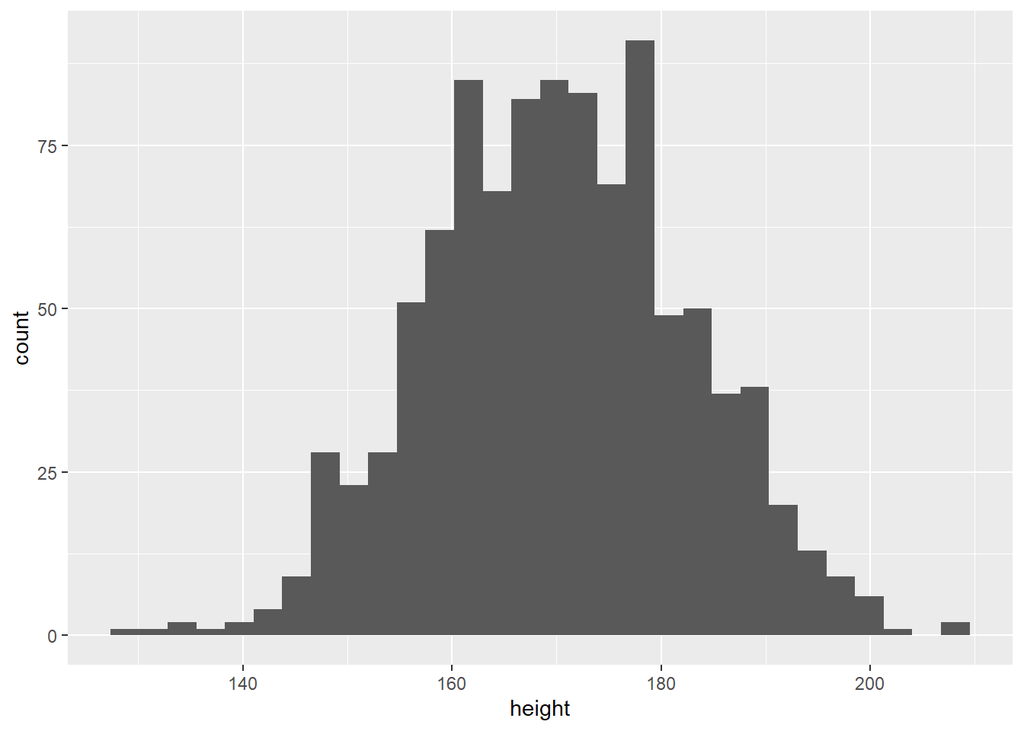

```r
library(ggplot2) # make sure ggplot2 is loaded int your environment


ggplot(data = pirates, aes(x = height)) + geom_histogram()         # histogram
```

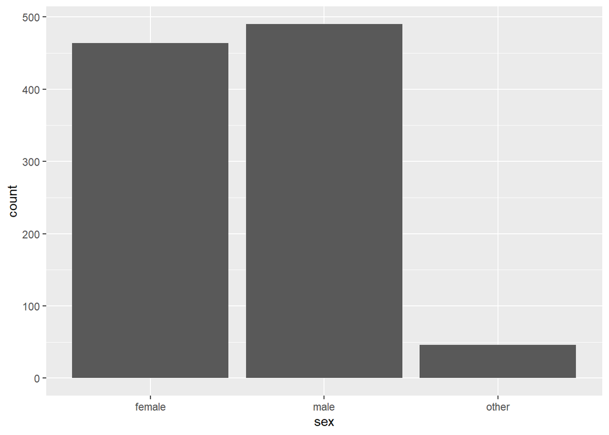

```r
ggplot(data = pirates, aes(x = sex))+ geom_bar()                   # barplot
```

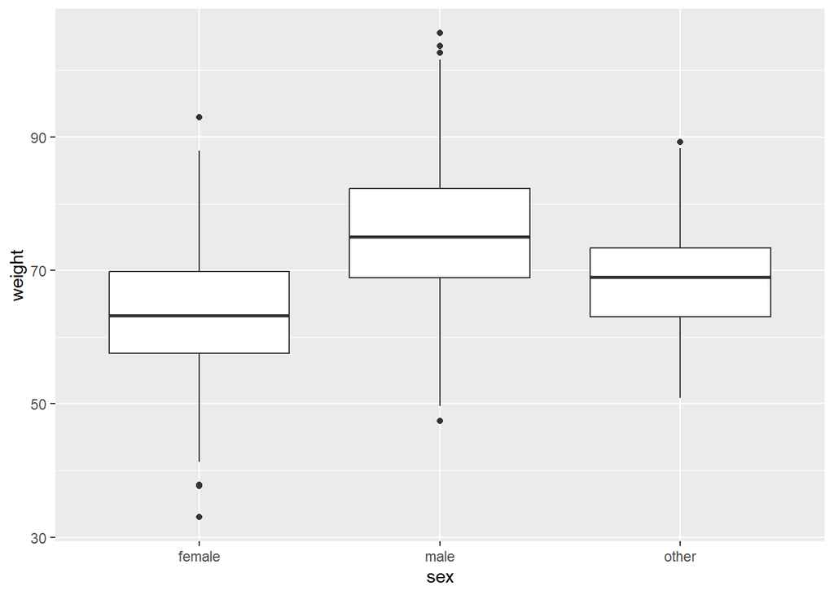

```r
ggplot(data = pirates, aes(x = sex, y = weight)) + geom_boxplot()  # boxplot
```

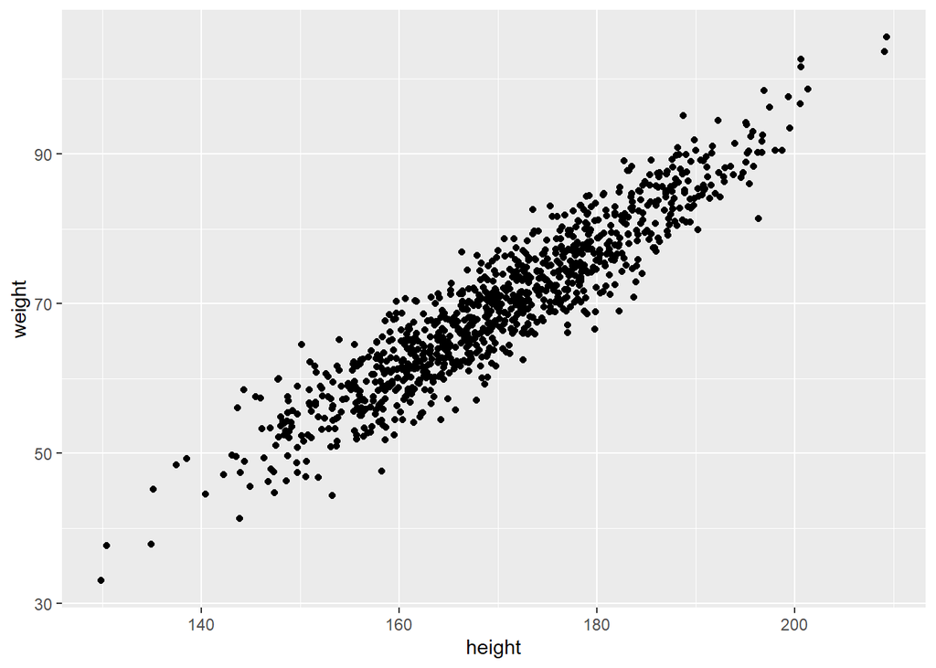

```r
ggplot(data = pirates, aes(x = height, y = weight)) + geom_point() # scatterplot
```

Lets break this code down a little bit. First, lets run the first part of the code (the first ‘layer’ without the bit after the + sign (the second ‘layer’).

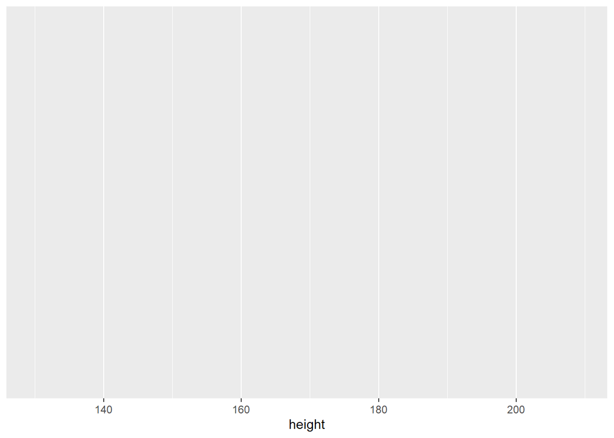

```r
ggplot(data = pirates, aes(x = height))
```

That looks weird right? There is no data shown. You have told ggplot2 to make a plot with height on the x axis, using the dataset pirates, but you havent told it what kind of plot you want. In the next line, you need to add one of the following layers depending on what type of plot you want.

| Plot type | ggplot layer syntax | Data x axis | Data y axis |
| --- | --- | --- | --- |
| Histogram | **+geom_histogram()** | Continuous/Count | None |
| Bar plot | **+geom_bar()** | Categorical | None |
| Boxplot | **+geom_boxplot()** | Categorical | Continuous/Count |
| Scatter plot | **+geom_point()** | Continuous/Count | Continuous/Count |

Now lets add the layer to tell R that we want to plot a histogram by adding “+ geom_histogram()”.

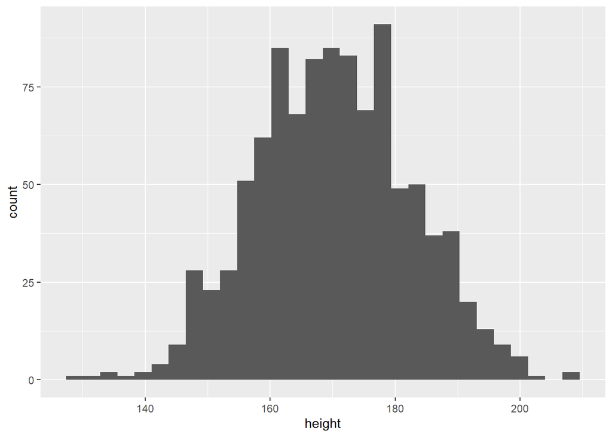

```r
ggplot(data = pirates, aes(x = height)) + geom_histogram()
```

## 11.1 Histograms

Histograms are probably the most important plot to know how to make, as they give you important information on the distribution of your *numerical* data. This will become very important later in the course when we are choosing statistical tests.

When making histograms, you only need to specify the x axis. This is because the y axis is not a column in your dataset, but represents a summary of your x axis variable.

Lets have a look at the distribution of parrot ownership in pirates. Note, you dont have to write ’data = pirates“, but just simply put”pirates".

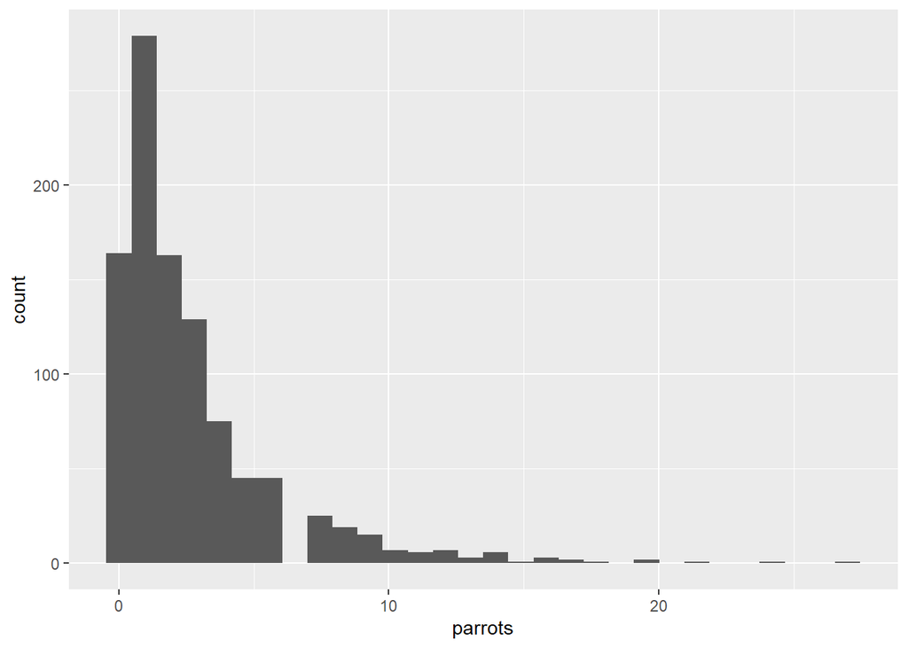

```r
ggplot(data = pirates, aes(x = parrots))+geom_histogram()
```

As you can see from the histogram, most pirates have between 0 and 3 parrots. However, there are a small number of pirates who love parrots so much that they have over 10 parrots. One even has over 25 parrots! This distribution is definitely not a normal (bell-curve) distribution, it is heavily right skewed! In fact, it is a perfect example of count data, which often tends to be right skewed.

## 11.2 **Exercise 5**

Make a histogram showing the distribution of tattoos across pirates. Copy in your plot below. To do this, click ‘Export’ and ‘Copy to clipboard’ in the menu above your plot.

[output not shown]

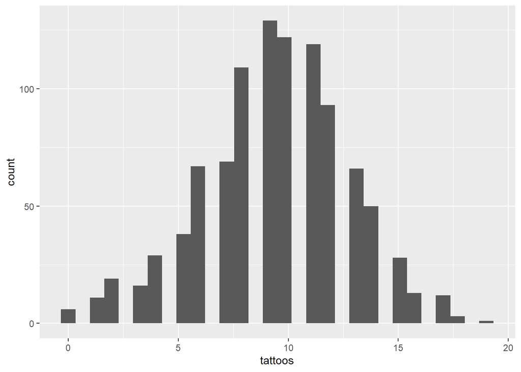

```r
ggplot(pirates, aes(x = tattoos))+geom_histogram()
```

**NOTE 1:** *ggplot2* syntax involves connecting multiple plotting layers with a + sign. You could put all layers on the same line, but most R users put each layer on a separate line to keep it tidy. However, because R treats every line as a stand alone piece of code, the + sign tells R that you’re not finished yet and it should move on to the next line. *Therefore, make sure the + goes at the end of the line, not at the beginning of the line below.*Otherwise, you will get an error.

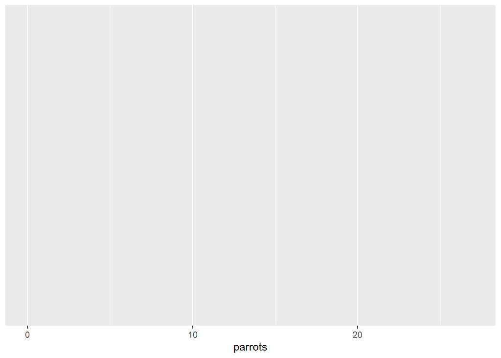

```r
ggplot(pirates, aes(x = parrots))
```

```r
  + geom_histogram()
```

```
## Error:
## ! Cannot use `+` with a single argument
## i Did you accidentally put `+` on a new line?
```

## 11.3 Barplots

Barplots are the equivalent of histograms but for categorical data: they show frequencies of categorical variables (i.e., how many observations do you have in your data per category?). As with histograms, you also don’t need a y variable. For example, they are good for showing how many pirates wear headbands compared to those who don’t:

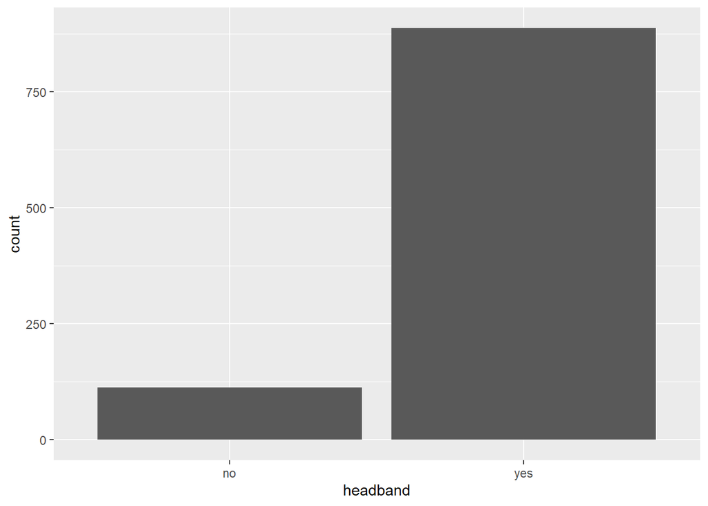

```r
ggplot(pirates, aes(x = headband))+geom_bar()
```

## 11.4 **Exercise 6**

Make a barplot showing the distribution of college attendance by pirates.

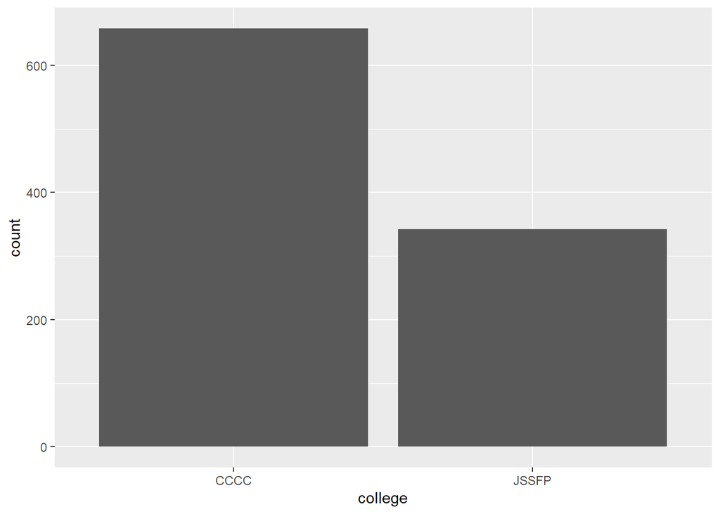

```r
ggplot(pirates, aes(x = college))+geom_bar()
```

## 11.5 Boxplots

Boxplots show you how a continuous variable differs between categories. They are probably the most common plot in scientific research. Lets have a look at beard length (*continuous data*) and self-reported sex (*categorical data*) in pirates.

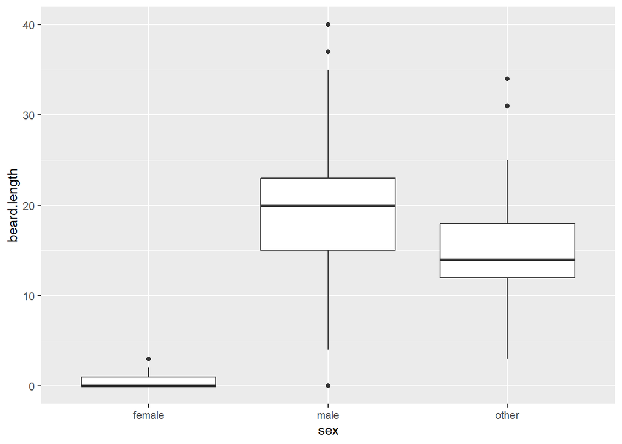

```r
ggplot(pirates, aes( x = sex, y = beard.length))+
  geom_boxplot()
```

## 11.6 **Exercise 7**

Make a boxplot that compares how long it takes to draw ones sword (*sword.time -* a continuous variable) across different sword types (*sword.type -* a categorical variable).

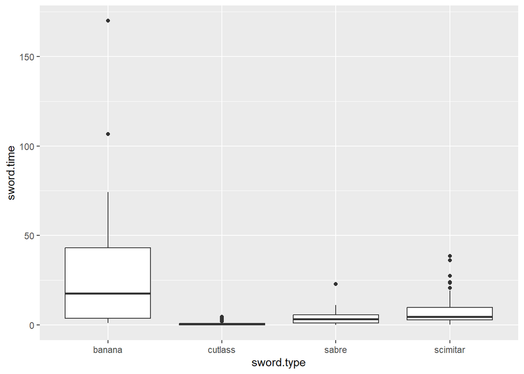

```r
ggplot(pirates, aes( x = sword.type, y = sword.time)) + geom_boxplot()
```

## 11.7 Scatter plots

Scatterplots are for looking at the relationship between two numerical variables. Because height and weight are numerical, the appropriate plot is a scatter plot. In general you want the variable that is being influenced on the y axis. In this case, height influences weight, so weight should go on the y axis. Weight does not influence height!

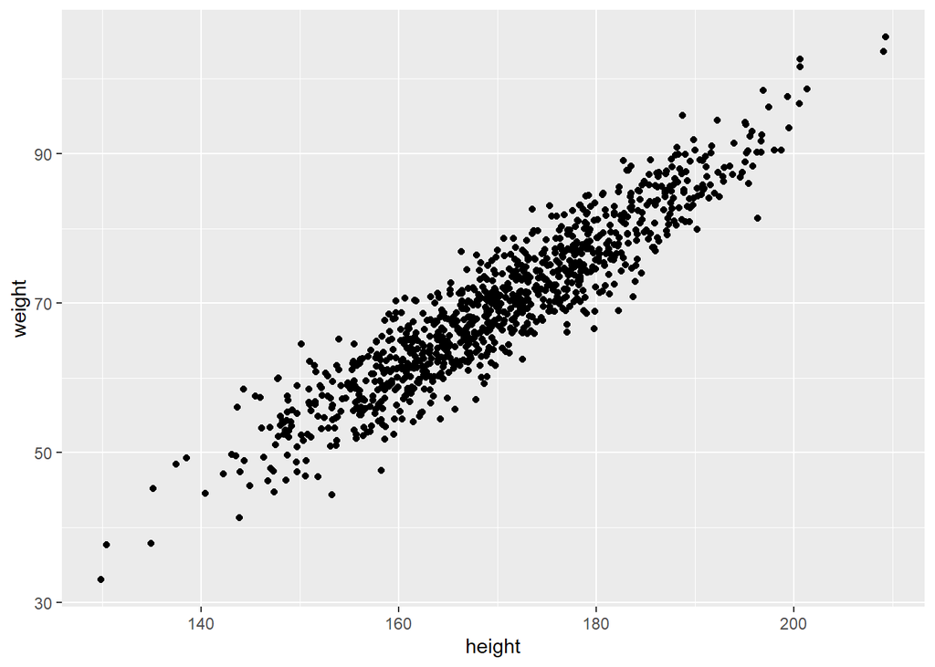

```r
ggplot(data = pirates, aes(x = height, y = weight))+ geom_point() # scatter plot
```

## 11.8 **Exercise 8**

Make scatter plot showing the relationship between age and number of treasure chests (*tchests*) found by pirates. Because age influences number of tchests found, tchests should go on the y axis.

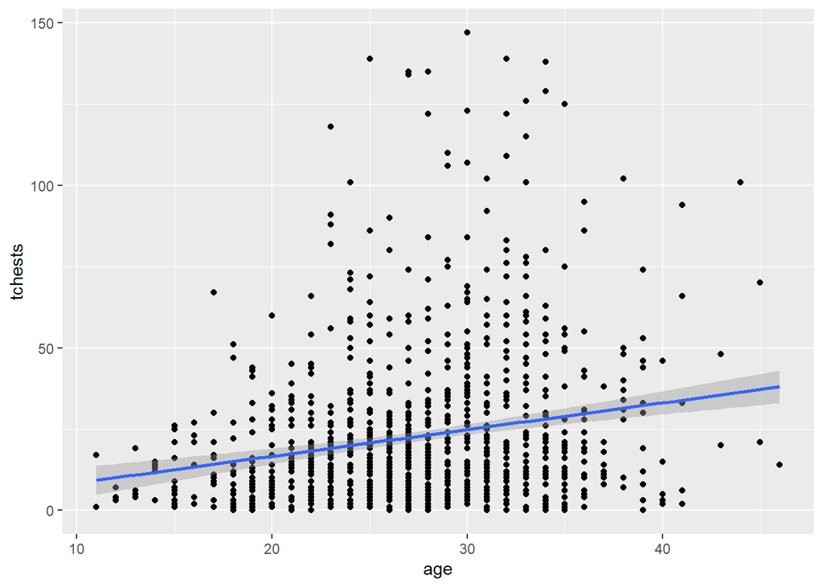

```r
ggplot(data = pirates, aes(x = age, y = tchests))+
  geom_point()+
  geom_smooth(method = "lm")
```

## 11.9 Adding titles and axis labels to plots

You can add titles and axis labels to the plot by additional additional layers to your code. Titles and labels are free text, which as mentioned above always needs to go in quotation marks.

Below is a table indicating the code you need to do this.

| What do you want to do? | ggplot2 layer | Example |
| --- | --- | --- |
| Add a title | +ggtitle() | **+ggtitle(“My title”)** |
| Change the x axis label | +xlab() | **+xlab(“My x label”)** |
| Change the y axis label | +ylab() | **+ylab(“My y label”)** |

Now lets make some plots with titles and axis labels.

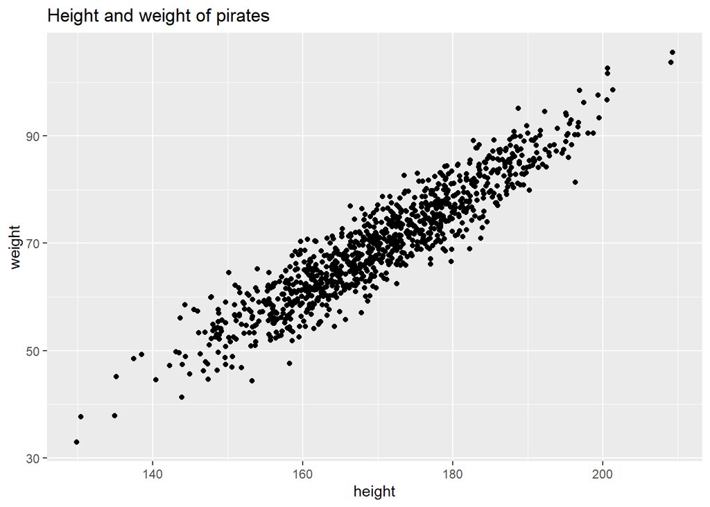

```r
# add a title

ggplot(data = pirates, aes(x = height, y = weight))+ # data and axes
  geom_point()+                                      # plot type
  ggtitle("Height and weight of pirates")            # add title
```

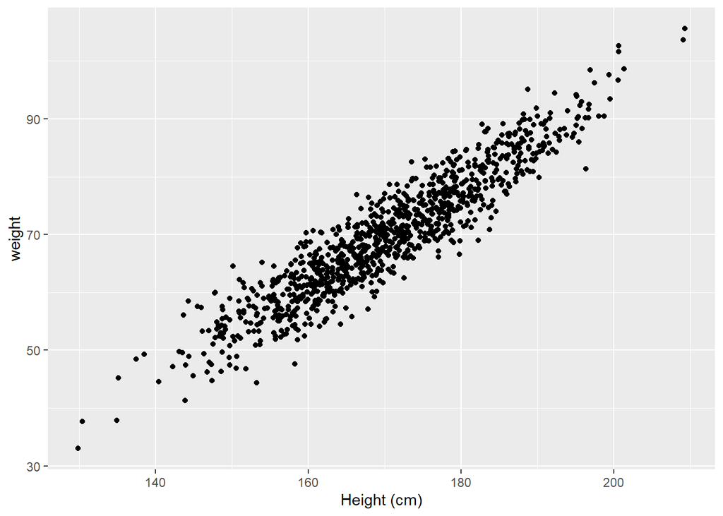

```r
# add an x-axis label
ggplot(data = pirates, aes(x = height, y = weight))+ # data and axes
  geom_point()+                                      # plot type
  xlab("Height (cm)")                                # add x axis label
```

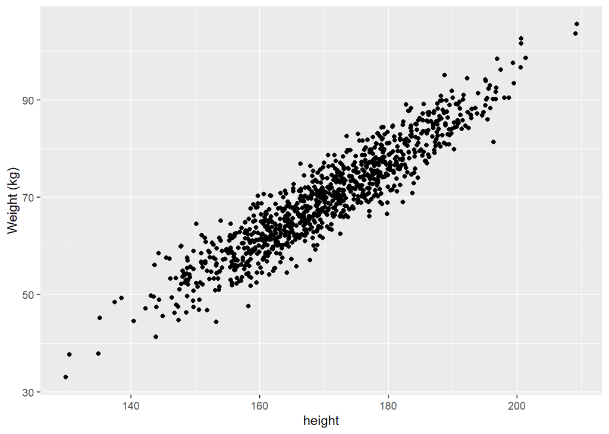

```r
# add a y-axis label
ggplot(data = pirates, aes(x = height, y = weight))+ # data and axes
  geom_point()+                                      # plot type
  ylab("Weight (kg)")                                # add y axis label
```

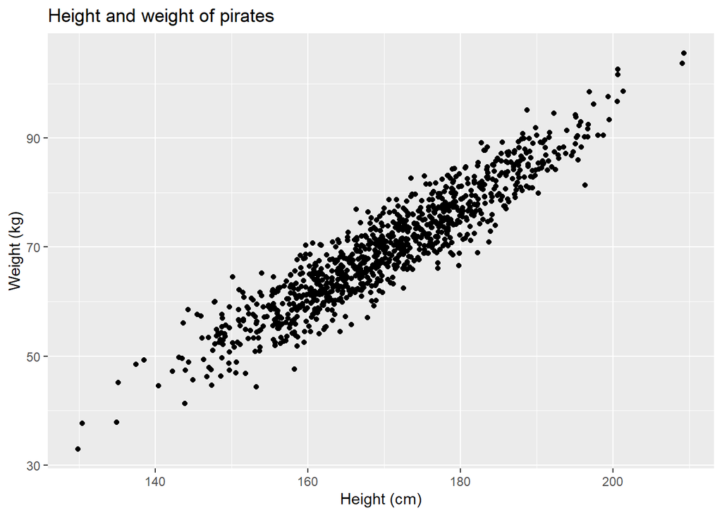

```r
####################################################################

# put them all together
ggplot(data = pirates, aes(x = height, y = weight))+ # data and axes
  geom_point()+                                      # plot type
  ggtitle("Height and weight of pirates")+           # add title
  xlab("Height (cm)")+                               # add x axis label
  ylab("Weight (kg)")                                # add y axis label
```

## 11.10 **Exercise 9**

Make a boxplot comparing pirate height across different sexes. Add a title (“Comparison of height across pirate sex”) and an x axis label (“Self-reported sex”) and a y axis label (“Height (cm)”).

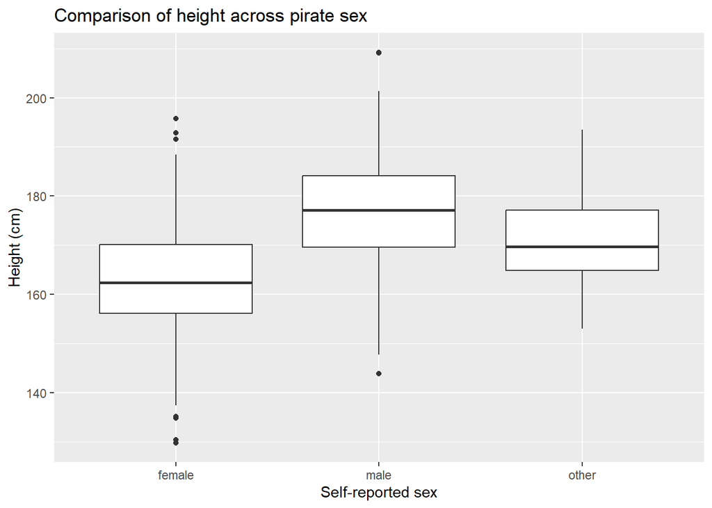

```r
ggplot(pirates, aes(x = sex, y = height))+
  geom_boxplot()+
  ggtitle("Comparison of height across pirate sex")+
  xlab("Self-reported sex")+
  ylab("Height (cm)")
```